# The Crisis of the Tax State Revisited

Artificial Intelligence, Business Conflict, and Digital Fiscal Capacity

Jacob Edenhofer

University of Oxford

Ben Ansell

University of Oxford

2026

## Motivation and research question

Schumpeter argued that a ‘crisis of old fiscal methods’ arises when economic transformation erodes the reliability of established sources of revenue (Schumpeter 1991, 101). By reducing the labour share of income, AI may well render rich democracies’ heavy reliance on labour taxation untenable, forcing them to increase other taxes, notably those on consumption and capital.

*Digital fiscal capacity* is the state’s legal and administrative ability to identify and value returns associated with AI and distinguish rents from normal returns. It is needed to implement targeted taxes on AI rents.

Greater legibility redistributes tax burdens among firms, making investment in this capacity a political choice.

Who benefits and who loses from digital fiscal capacity?  
When do policymakers have incentives to invest in building up this capacity?

Fiscal crisis and tax structure (Schumpeter 1991; Keen and Slemrod 2022; Cusack and Beramendi 2006; Beramendi and Rueda 2007; Korinek and Lockwood 2026)  
Digital fiscal capacity, legibility, and elite conflict (Beramendi, Dincecco, and Rogers 2019; Haskel and Westlake 2018; Farboodi and Veldkamp 2023; Healy et al. 2026; Fetzer, Shaw, and Edenhofer 2024; Scott 1999; Lee and Zhang 2017; Brambor et al. 2020; Garfias and Sellars 2026; Ansell and Samuels 2010)

## The argument in brief. Tax incidence and the demand for digital fiscal capacity

Voters determine the contribution required from capital to fund a given level of expenditure. The desired capital contribution increases with inequality. Digital fiscal capacity determines which types of firms bear this burden.

Low digital fiscal capacity

Blunt capital taxation

Conventional firms bear a disproportionate share

High digital fiscal capacity

Targeted taxation of AI rents

Part of the capital contribution shifts to AI firms

Capacity reduces the expected tax burden of conventional firms.

Fiscal stakes rise as fiscal erosion, inequality, and the share shifted to AI firms increase the tax saving relative to the political cost of inducing investment; transition speed and relative political power then determine whether investment is anticipatory, reactive, or absent.

Distributional conflict over fiscal legibility (Fetzer, Shaw, and Edenhofer 2024)· Tax policy after AI (Korinek and Lockwood 2026)

## Model setup and assumptions

We use a Markov model with an infinite horizon in which the conventional sector chooses whether to incur a political cost in order to induce government investment.

State and assumptions

- The state is $z=(s,a)$, where $s\in\{\mathord{\ell},h\}$ denotes the fiscal environment, $a=0$ denotes blunt taxation and $a=1$ denotes targeted capacity. Investment is delayed and capacity durable.
- Public expenditure is constant.
- $i_s$ is inequality and $\alpha(i_s)\in[0,1]$ the share of the fiscal shortfall assigned to capital; $\alpha'(i_s)\geq0$.
- Relative political power determines the effective political cost $k_s$ in each state.

Tax incidence ($N$ denotes conventional firms; $A$ denotes AI firms)

$$K_s=
\underbrace{\alpha(i_s)}_{\text{capital share}}
\;\cdot\;
\underbrace{S_s}_{\text{fiscal shortfall}}.$$

$$\begin{aligned}
T_N(s,a)&=\underbrace{\zeta K_s}_{\text{baseline burden}}
-\underbrace{a\chi K_s}_{\text{shifted to AI firms}},\\[4pt]
T_A(s,a)&=\underbrace{(1-\zeta)K_s}_{\text{baseline burden}}
+\underbrace{a\chi K_s}_{\text{same amount}}.
\end{aligned}$$

The conventional sector’s share of the burden falls from $\zeta$ to $r$, with $0<r<\zeta<1$; $\chi\equiv\zeta-r$ is the share shifted to AI rents. Capacity saves $x_s=\chi K_s$ in each period; write $X\equiv x_h$ after the transition.

Capacity leaves the capital contribution $K_s$ unchanged and reallocates $\chi K_s$ from conventional firms to AI firms.

Fiscal legibility and informational capacity (Scott 1999; Brambor et al. 2020; Garfias and Sellars 2026)

Incidence details →Dynamic programme →

## Conceptualising the AI transition

The transition is an exogenous shift between two fiscal and political environments.

Before the transition

Economic state<sup>1</sup> $\ell$  
Fiscal shortfall $S_\ell=0$  
Inequality $i_\ell$  
Political cost<sup>2</sup> $k_\ell=c$

Anticipatory investment

Firms pay $c$ before receiving tax savings. Capacity becomes effective one period later.

transition probability $\pi$

After the transition

Economic state<sup>1</sup> $h$ is absorbing  
Fiscal shortfall $S_h=S$  
Inequality $i_h\geq i_\ell$  
Political cost<sup>2</sup> $k_h=c/\rho$

Reactive investment

Firms wait, face one period of blunt taxation, and may then pay $c/\rho$.

Investment takes one period to become effective and then persists. A lower $\rho$ raises the political cost of reactive investment.

<sup>1</sup> “Economic state” indexes whether the economy is before ($\ell$) or after ($h$) the AI transition; it determines the fiscal shortfall, inequality, and relative political power.

<sup>2</sup> “Political cost” is mobilisation expenditure borne by conventional firms. The parameter $c>0$ denotes its level before the transition. The parameter $\rho\in(0,1]$ compares firms’ political effectiveness after the transition with their effectiveness before it. Hence $k_h=c/\rho$.

Preventive investment under anticipated power shifts (Fearon 1995; Callander 2026)

Transition value →Political cost →

## The investment problem

$\beta\in(0,1)$ is the discount factor for one period; $X\equiv x_h=\chi\alpha(i_h)S>0$ is the saving after the transition; the cut-offs are expressed in $X$, while the figures plot $X/c$.

$$\underbrace{q}_{\text{expected discount factor at transition}}
=\frac{\beta\pi}{1-\beta(1-\pi)}.$$

Reactive investment

$\displaystyle R(\rho)=\underbrace{\frac{1-\beta}{\beta}}_{\text{discounting}}\quad\cdot\quad\underbrace{\frac{c}{\rho}}_{\text{later cost}}$

The discounted stream of savings must cover $c/\rho$.

Anticipatory without reaction

$\displaystyle A_N=\frac{\overbrace{(1-\beta)c}^{\text{current cost}}}{\underbrace{q}_{\text{transition timing}}}$

Waiting leaves capacity permanently low.

Anticipatory with reaction

$\displaystyle A_R(\rho)=\underbrace{\frac{c}{q}}_{\text{act now}}-\underbrace{\frac{c}{\rho}}_{\text{act later}}$

Waiting preserves the option to react.

Which anticipatory cut-off applies depends on whether reactive investment remains possible. The boundaries meet at the critical threshold for relative political power $\rho^*=q/\beta$.

Cut-off logic →

## Stationary Markov perfect equilibrium

A stationary Markov perfect equilibrium is a strategy $\sigma^*$ that depends only on $(s,a)$ and maximises the conventional sector’s continuation payoff at every state.

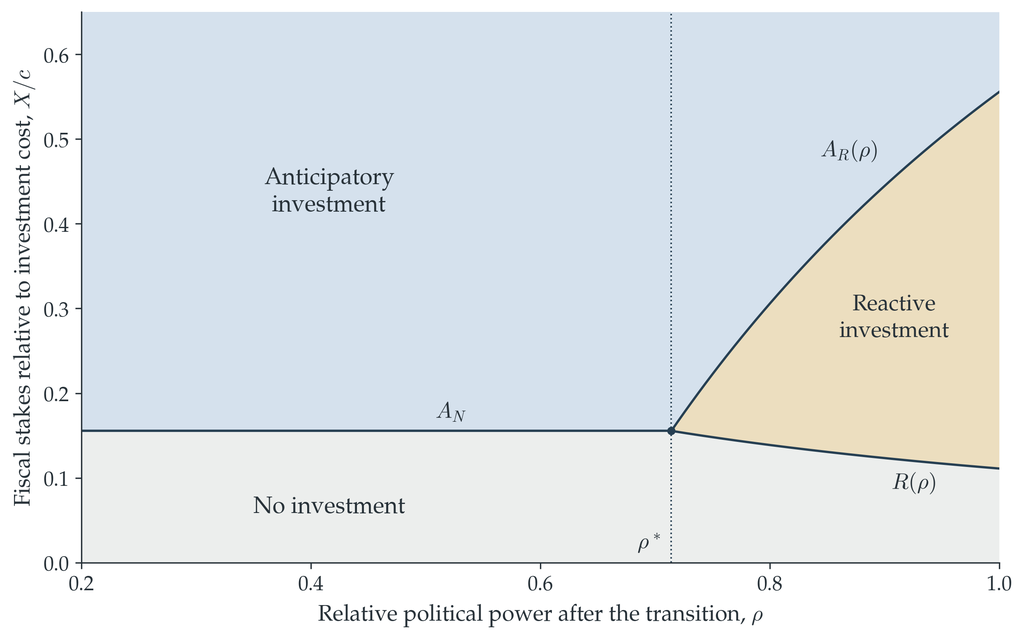

The illustration uses $\beta=0.90$ and $\pi=0.20$. The regions describe equilibrium paths from $(ℓ,0)$.

Below $\rho^*$, the equilibrium path contains anticipatory investment or no investment. Above it, reactive investment can occur at intermediate fiscal stakes.

Regime orderings →

## Comparative statics for fiscal stakes

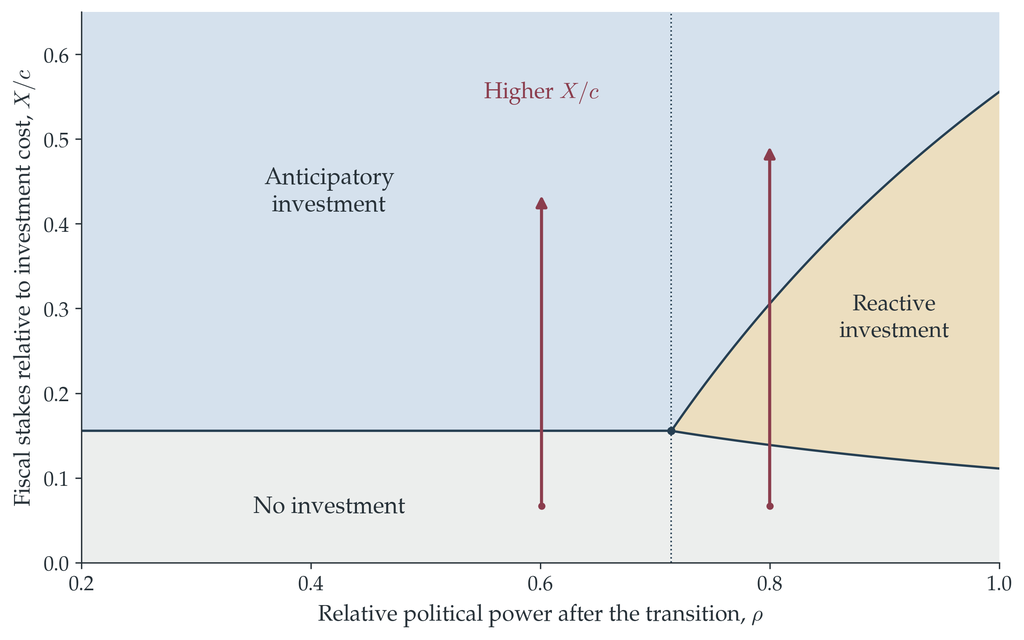

Higher fiscal stakes cross the investment cut-offs.

Derivations →Complete figure →

## Comparative statics for speed of transition

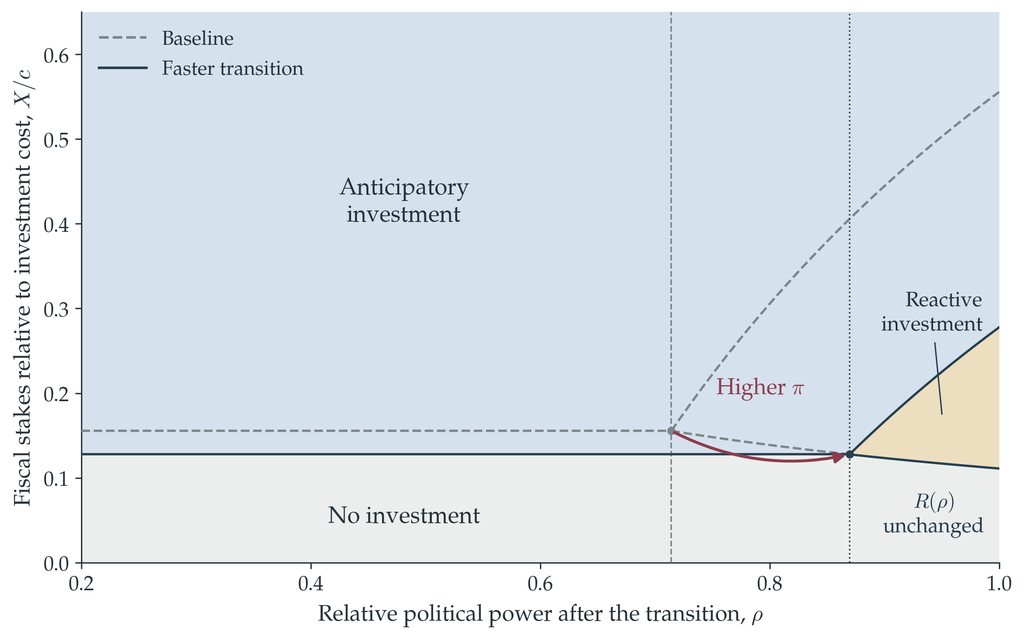

A faster transition lowers both anticipatory cut-offs, raises $\rho^*$, and leaves $R(\rho)$ unchanged.

Derivations →Complete figure →

## Fiscal stakes determine the effect of lower relative political power

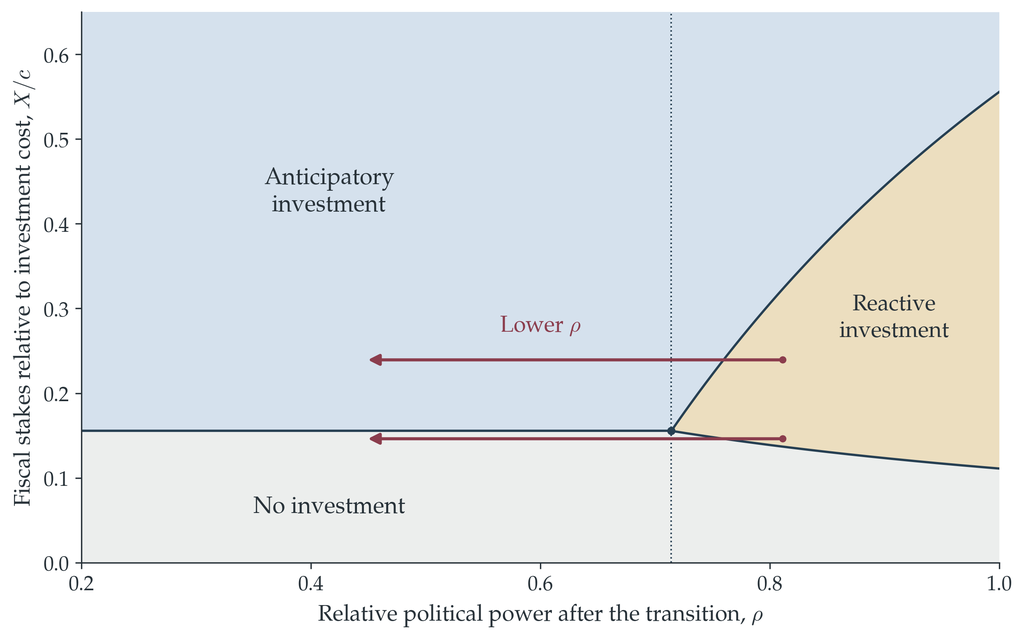

After a sufficiently large fall in $\rho$, reactive investment gives way to anticipatory investment above $A_N$ and to no investment below $A_N$.

Preventive action and the rise of a new interest group (Fearon 1995; Callander 2026)

Derivations →

## Discussion and extensions

Robustness of the central mechanism. Reducing the expected duration of capacity or weakening the commitment to use it raises the minimum fiscal stake required for investment. The incidence conflict changes only if commitment becomes tied to political power.<sup>1</sup>

Energy taxation as an observable substitute

- Kasy (2025) calls energy a “means of prediction”; physical energy use is easier to observe than intangible AI rents.
- A levy on the electricity consumed by AI systems can raise revenue without first identifying and valuing AI rents. It may therefore require less digital fiscal capacity.
- It is a close substitute only when the levy yields substantial revenue from AI rents that firms cannot readily avoid. Taxes on FLOPS and tokens still require substantial measurement and enforcement (Irwin, Wu, and Barez 2026).

Imperfect commitment and persistence

- If commitment is represented by the same constant probability of use after early or late investment, all cut-offs scale equally; the regime ordering and $\rho^*$ do not change.
- A reversible transition similarly shortens the period of fiscal savings without changing the incidence mechanism.
- If the probability of using available capacity falls with conventional firms’ relative power, anticipatory investment can weaken or reverse.

Partial substitution reduces the effective fiscal stake; imperfect commitment that is independent of political power raises the cut-offs. If commitment weakens sufficiently as $\rho$ falls, the anticipatory result can reverse.

<sup>1</sup> Broad capital ownership across the income distribution can weaken or reverse the assumed positive relation between inequality and voters’ preferred capital share of taxation (Atkinson 2015).

Commitment extension →

## Conclusion

Fiscal stakes, transition speed, and relative political power determine whether investment is anticipatory, reactive, or absent.

The resolution of Schumpeter’s crisis in an era of AI depends on whether firms burdened by old fiscal methods can induce investment before AI firms acquire sufficient power to block it (Schumpeter 1991, 101).

As Acemoglu and Restrepo (2018) argue, there is a race between man and machine as the latter substitutes for the former. There is also a new race between firms that traditionally relied on humans and those whose profits come from a brave new world of AI agents with extraordinary intelligence.

How that political battle resolves will determine the future structure of the fiscal state.

## References (1/3)

Acemoglu, Daron, and Pascual Restrepo. 2018. ‘The Race Between Man and Machine: Implications of Technology for Growth, Factor Shares, and Employment’. *American Economic Review* 108 (6): 1488–1542. [DOI 10.1257/aer.20160696](https://doi.org/10.1257/aer.20160696).

Ansell, Ben, and David Samuels. 2010. ‘Inequality and Democratization: A Contractarian Approach’. *Comparative Political Studies* 43 (12): 1543–74. [DOI 10.1177/0010414010376915](https://doi.org/10.1177/0010414010376915).

Atkinson, Anthony B. 2015. *Inequality: What Can Be Done?* Cambridge, MA: Harvard University Press. [DOI 10.4159/9780674287013](https://doi.org/10.4159/9780674287013).

Beramendi, Pablo, Mark Dincecco, and Melissa Ziegler Rogers. 2019. ‘Intra-Elite Competition and Long-Run Fiscal Development’. *The Journal of Politics* 81 (1): 49–65. [DOI 10.1086/700273](https://doi.org/10.1086/700273).

Beramendi, Pablo, and David Rueda. 2007. ‘Social Democracy Constrained: Indirect Taxation in Industrialized Democracies’. *British Journal of Political Science* 37 (4): 619–41. [DOI 10.1017/S0007123407000348](https://doi.org/10.1017/S0007123407000348).

Brambor, Thomas, Agustín Goenaga, Johannes Lindvall, and Jan Teorell. 2020. ‘The Lay of the Land: Information Capacity and the Modern State’. *Comparative Political Studies* 53 (2): 175–213. [DOI 10.1177/0010414019843432](https://doi.org/10.1177/0010414019843432).

Callander, Steven. 2026. ‘Regulating AI: The Race Between Policymakers and the Rise of a New Interest Group’. In *The Political Economy of Artificial Intelligence*, edited by Ajay Agrawal, Joshua Gans, Avi Goldfarb, and Catherine E. Tucker, 39–44. Chicago, IL: University of Chicago Press.

Carvalho, Jean-Paul. 2025. ‘The Political-Economic Risks of AI’. Preprint 5137622. SSRN. [DOI 10.2139/ssrn.5137622](https://doi.org/10.2139/ssrn.5137622).

## References (2/3)

Cusack, Thomas R., and Pablo Beramendi. 2006. ‘Taxing Work’. *European Journal of Political Research* 45 (1): 43–73. [DOI 10.1111/j.1475-6765.2005.00290.x](https://doi.org/10.1111/j.1475-6765.2005.00290.x).

Denisenko, Anna, and Konstantin Sonin. 2026. ‘When the Middle Class Undermines Progress: The Political Economy of AI Regulation’. SSRN Scholarly Paper 7349703. Social Science Research Network. [DOI 10.2139/ssrn.7349703](https://doi.org/10.2139/ssrn.7349703).

Egorov, Georgy, and Konstantin Sonin. 2026. ‘Artificial Intelligence and Political Advice’. Working Paper 2026-117. Becker Friedman Institute. [BFI working paper](https://bfi.uchicago.edu/working-papers/artificial-intelligence-and-political-advice/).

Farboodi, Maryam, and Laura Veldkamp. 2023. ‘Data and Markets’. *Annual Review of Economics* 15: 23–40. [DOI 10.1146/annurev-economics-082322-023244](https://doi.org/10.1146/annurev-economics-082322-023244).

Farboodi, Maryam, and Laura L. Veldkamp. 2026. ‘A Model of the Data Economy’. *The Review of Economic Studies*, July, rdag074. [DOI 10.1093/restud/rdag074](https://doi.org/10.1093/restud/rdag074).

Fearon, James D. 1995. ‘Rationalist Explanations for War’. *International Organization* 49 (3): 379–414. [DOI 10.1017/S0020818300033324](https://doi.org/10.1017/S0020818300033324).

Fetzer, Thiemo, Callum Shaw, and Jacob Edenhofer. 2024. ‘Informational Boundaries of the State’. 10901. CESifo Working Paper Series.

Garfias, Francisco, and Emily A. Sellars. 2026. ‘Fiscal Legibility and State Development: Theory and Evidence from Colonial Mexico’. *American Journal of Political Science* 70 (1): 5–20. [DOI 10.1111/ajps.12901](https://doi.org/10.1111/ajps.12901).

Haskel, Jonathan, and Stian Westlake. 2018. *Capitalism Without Capital: The Rise of the Intangible Economy*. Princeton: Princeton University Press. [DOI 10.1515/9781400888320](https://doi.org/10.1515/9781400888320).

## References (3/3)

Healy, Patrick, Simon D. Angus, Paul Raschky, Klaus Ackermann, Nathan Lane, Weijia Li, and Cynthia A. Huang. 2026. ‘Digital State Capacity’. arXiv preprint arXiv:2608.03221. [DOI 10.48550/arXiv.2608.03221](https://doi.org/10.48550/arXiv.2608.03221).

Irwin, Lucas, Tung-Yu Wu, and Fazl Barez. 2026. ‘Token Taxes: Mitigating AGI’s Economic Risks’. arXiv preprint arXiv:2603.04555. [DOI 10.48550/arXiv.2603.04555](https://doi.org/10.48550/arXiv.2603.04555).

Kasy, Maximilian. 2025. *The Means of Prediction: How AI Really Works (and Who Benefits)*. Chicago: University of Chicago Press. [DOI 10.7208/chicago/9780226839547.001.0001](https://doi.org/10.7208/chicago/9780226839547.001.0001).

Keen, Michael, and Joel Slemrod. 2022. *Rebellion, Rascals, and Revenue: Tax Follies and Wisdom Through the Ages*. Princeton; Oxford: Princeton University Press. [DOI 10.1515/9780691199986](https://doi.org/10.1515/9780691199986).

Korinek, Anton, and Lee Lockwood. 2026. ‘Public Finance in the Age of AI: A Primer’. NBER Working Paper w34873. National Bureau of Economic Research. [DOI 10.3386/w34873](https://doi.org/10.3386/w34873).

Lee, Melissa M., and Nan Zhang. 2017. ‘Legibility and the Informational Foundations of State Capacity’. *The Journal of Politics* 79 (1): 118–32. [DOI 10.1086/688053](https://doi.org/10.1086/688053).

Schumpeter, Joseph A. 1991. *Joseph A. Schumpeter: The Economics and Sociology of Capitalism*. Edited by Richard Swedberg. Princeton, NJ: Princeton University Press. [DOI 10.2307/j.ctv173f01t](https://doi.org/10.2307/j.ctv173f01t).

Scott, James C. 1999. *Seeing Like a State: How Certain Schemes to Improve the Human Condition Have Failed*. New Haven: Yale University Press. [DOI 10.12987/9780300128789](https://doi.org/10.12987/9780300128789).

## Appendix

Derivations and extensions

## From the fiscal gap to the capital contribution

Let $\bar G>0$ denote committed public spending. Let $R_s^0$ denote revenue from the existing tax system. The residual fiscal shortfall is

$S_s=$ $\bar G$ $-$ $R_s^0$

Before the transition$S_\ell=0$. The existing tax system funds spending.

After the transition$S_h=S>0$. The erosion of revenue leaves a fiscal gap.

Voters then determine how much of that gap capital must finance.

$K_s=$ $\underbrace{\alpha(i_s)}_{\text{capital share}}$ $\cdot$ $\underbrace{S_s}_{\text{fiscal gap}}$ $,\quad \alpha'(i)\geq0.$

The transition creates the fiscal gap. Inequality determines the share financed through taxes on capital.

← Model setupWho pays? →

## Digital capacity changes who pays

Voters determine the capital contribution $K_s$. Capacity reallocates it across sectors.

$T_N(s,a)=$ $\zeta K_s$ $-$ $\underbrace{a\chi K_s}_{\text{shifted to AI rents}}$

$T_A(s,a)=$ $(1-\zeta)K_s$ $+$ $a\chi K_s$

$T_N(s,a)+T_A(s,a)=K_s$ for either level of capacity.

With $\chi\equiv\zeta-r>0$, the conventional sector’s saving in each period is

$x_s$ $\equiv T_N(s,0)-T_N(s,1)=$ $\underbrace{\chi K_s}_{\text{burden reallocated}}$

Hence $x_\ell=0$ and $x_h=X=\chi\alpha(i_h)S$. Capacity reallocates $K_s$ across sectors while leaving its total unchanged.

← Fiscal gap← Model setup

## State, action, and capacity accumulation

The state $(s_t,a_t)$ contains all information from the past that affects the current decision. Earlier history has no independent effect once the state is known.

$\displaystyle z_t=(s_t,a_t)\in\{\mathord{\ell},h\}\times\{0,1\}.$

The binary action $I_t\in\{0,1\}$ records whether conventional firms successfully induce government investment. It is feasible only when capacity is absent. Thus $\mathcal I(0)=\{0,1\}$ and $\mathcal I(1)=\{0\}$. Capacity evolves as

$a_{t+1}=$ $\underbrace{a_t}_{\text{existing capacity}}$ $+$ $\underbrace{(1-a_t)I_t}_{\text{new capacity}}$

If $a_t=0$$a_{t+1}=I_t$. Investment becomes usable next period.

If $a_t=1$$a_{t+1}=1$. Capacity remains available.

The action at $t$ determines capacity at $t+1$. Investment takes one period to become effective, and capacity remains available thereafter.

← Model setupPayoff timing →

## The timing of benefits and costs

The normalisation removes the tax term that is constant across investment choices. The conventional sector’s current payoff is

$u(s,a,I)=$ $\underbrace{a x_s}_{\text{current tax saving}}$ $-$ $\underbrace{k_s I}_{\text{mobilisation cost}}$

BenefitThe saving $x_s$ is received only when capacity is already available, with $a=1$.

CostFirms pay the political cost $k_s$ immediately when they induce investment, with $I=1$.

TimingBecause $I_t$ changes $a_{t+1}$, investment today cannot reduce today’s tax burden.

The savings satisfy $x_\ell=0$ and $x_h=X$. The political costs satisfy $k_\ell=c$ before the transition and $k_h=c/\rho$ after it.

Firms pay investment costs in the current period. Capacity affects taxation from the next period onwards and remains available thereafter.

The omitted term $-\zeta K_s$ is the same under both actions because investment does not change the current tax base or the transition probability. The normalisation changes payoff levels while leaving choices unchanged.

← State and timingBellman principle →

## The Bellman principle and sequential decisions

$V(s,a)$ denotes the maximum expected discounted sum of the conventional sector’s normalised payoffs from state $(s,a)$ under optimal choices in the current and all subsequent periods.

$\displaystyle \underbrace{V(s,a)}_{\text{value from now on}} =\max_{I\in\mathcal I(a)}\left\{ \underbrace{u(s,a,I)}_{\text{payoff now}} + \underbrace{\beta\,\mathbb E[V(s',a')\mid s,a,I]}_{\text{best discounted value tomorrow}} \right\}.$

StateThe state $(s,a)$ contains all information from the past that affects the current choice.

ChoiceThe maximum compares the lifetime consequences of each feasible action.

RecursionThe value $V$ recurs. Once tomorrow’s state is realised, firms face the same optimisation problem.

The Bellman equation rewrites the problem over an infinite horizon as a comparison for one period that repeats after the state changes.

← Payoff timingModel equation →

## The Bellman equation in this model

Inherited capacity determines the current saving. Investment changes the cost paid now and the capacity available tomorrow.

$V(s,a)=$ $\underbrace{a x_s}_{\text{current saving}}$ $+\max_{I\in\mathcal I(a)}$ { $\underbrace{-k_sI}_{\text{cost now}}$ $+$ $\underbrace{\beta\sum_{s'}P_{ss'}V\!\left(s',a+(1-a)I\right)}_{\text{discounted continuation value}}$ }.

Inherited capacityThe maximisation excludes $a x_s$ because today’s action cannot change today’s tax saving.

Choice todayWhen $a=0$, the maximum compares $I=0$ with $I=1$; mobilisation cost $k_sI$ is paid immediately.

Tomorrow’s state$\beta\in(0,1)$ discounts the future, $P_{ss'}$ captures uncertainty, and $I$ determines next period’s capacity.

Firms invest when the increase in discounted value from capacity in the next period covers the mobilisation cost incurred in the current period.

← Bellman principleFour states →

## Four states and two decision states

Write $V_s\equiv V(s,0)$ for absent capacity and $W_s\equiv V(s,1)$ for available capacity. Durability means that only the two states with $a=0$ admit an investment choice.

|  | Capacity absent $a=0$ | Capacity available $a=1$ |
| --- | --- | --- |
| Before the transition $s=\ell$ | **$V_\ell$** Choose anticipatory investment or wait. $\max\{-c+W_\ell,\;\beta[(1-\pi)V_\ell+\pi V_h]\}$ | **$W_\ell$** Capacity survives until the transition. $\beta[(1-\pi)W_\ell+\pi W_h]$ |
| After the transition $s=h$ | **$V_h$** Choose reactive investment or remain subject to blunt taxation. $\max\{\beta V_h,\;-c/\rho+\beta W_h\}$ | **$W_h$** Receive $X$ in every period. $X+\beta W_h$ |

Solution order $W_h\;\longrightarrow\;W_\ell\;\longrightarrow\;V_h\;\longrightarrow\;V_\ell$

Solve the absorbing state with available capacity first, then work backwards to the reactive and anticipatory decisions.

← Bellman equationTransition value →

## The discounted proximity of the transition

The transition time $\tau$ has a geometric distribution

$$\Pr(\tau=n)=\pi(1-\pi)^{n-1}.$$

Therefore

$$\begin{aligned}
q
&=\mathbb E[\beta^\tau\mid s_0=\ell]\\
&=\sum_{n=1}^{\infty}\beta^n\pi(1-\pi)^{n-1}\\
&=\frac{\beta\pi}{1-\beta(1-\pi)}.
\end{aligned}$$

$q$ is the expected discount factor until benefits begin. It increases with transition speed and patience. It differs from both the transition probability and the expected transition time.

With $W_s\equiv V(s,1)$ denoting the value of available capacity, these values are

$W_h=$ $\underbrace{\frac{X}{1-\beta}}_{\text{perpetual saving after transition}}$ $,\qquad W_\ell=$ $\underbrace{q}_{\text{delay until transition}}$ $W_h.$

← AI transitionCut-offs →

## Three cut-offs and their points of indifference

At each decision state, firms compare immediate investment with one relevant alternative. A cut-off specifies the saving in each period at which the expected lifetime payoffs from the two choices are equal.

$\Delta(X)\equiv$ value of investing now $-$ value of the alternative, $\qquad \Delta(\bar X)=0.$

| Cut-off | Decision point | Consequence of waiting |
| --- | --- | --- |
| $R(\rho)$ | After the transition | They never invest. |
| $A_N$ | Before the transition; $X<R(\rho)$ | Reaction is unprofitable, and firms never invest. |
| $A_R(\rho)$ | Before the transition; $X\geq R(\rho)$ | They wait for the transition and then react. |

The persistence of waiting. If the economy remains in $(\ell,0)$, neither component of the state changes. A stationary strategy therefore prescribes waiting until state $h$ arrives.

Each decision point offers two actions. The three cut-offs differ because the consequences of waiting vary across states.

← Transition valueFirst derivation →

## Deriving the reactive cut-off

After the transition, conventional firms compare never investing with investing immediately.

$V_h\equiv V(h,0)=\max$ { $\underbrace{0}_{\text{never invest}}$ , $\underbrace{-\frac{c}{\rho}+\frac{\beta X}{1-\beta}}_{\text{invest now}}$ }.

Investment is optimal when discounted savings cover the political cost after the transition.

$\underbrace{\frac{\beta X}{1-\beta}}_{\text{discounted savings}}$ $\geq$ $\underbrace{\frac{c}{\rho}}_{\text{cost of reacting}}$

$$X\geq R(\rho)
\equiv\frac{(1-\beta)c}{\beta\rho}.$$

$R(\rho)$ is the minimum saving in each period that makes reactive investment worthwhile. The transition has already occurred, which removes $\pi$ from the expression.

← Investment problemNext derivation →

## Deriving the anticipatory cut-off without reaction

When reactive investment is unprofitable, waiting leaves capacity absent and has value zero.

Relevant branch $X<R(\rho)$.

Immediate investment is optimal when expected future savings cover the political cost paid before the transition.

$\underbrace{-c}_{\text{cost now}}$ $+$ $\underbrace{\frac{qX}{1-\beta}}_{\text{future tax savings}}$ $\geq$ $0$

Hence

$$X\geq A_N
\equiv
\frac{\overbrace{(1-\beta)c}^{\text{current cost in flow units}}}
{\underbrace{q}_{\text{benefits are delayed}}}.$$

$A_N$ is the minimum saving in each period that justifies paying $c$ before benefits begin. Firms that wait never invest in this case.

← Investment problemNext derivation →

## Deriving the anticipatory cut-off with reaction

When reactive investment remains profitable, waiting preserves an option to act later.

Relevant branch $X\geq R(\rho)$.

Invest now$-c$$+$$\frac{qX}{1-\beta}$

Wait, then react$q$ [$-\frac{c}{\rho}$$+$$\frac{\beta X}{1-\beta}$]

Subtracting the value of waiting gives the intuitive comparison

$\underbrace{qX}_{\text{avoid one period of blunt taxation}}$ $+$ $\underbrace{\frac{qc}{\rho}}_{\text{avoid later mobilisation}}$ $\geq$ $\underbrace{c}_{\text{mobilise now}}$

Rearranging gives

$$X\geq A_R(\rho)
\equiv\frac{c}{q}-\frac{c}{\rho}.$$

$A_R(\rho)$ is the saving that makes immediate investment as valuable as waiting. Immediate investment avoids one period of blunt taxation and incurs the lower political cost available before the transition.

← Investment problemCritical power →

## The critical value $\rho^*$ and the feasibility of reaction

The cut-off for reactive investment and the anticipatory cut-off that applies when reaction is unavailable coincide when

$$R(\rho)=A_N
\quad\Longleftrightarrow\quad
\rho=\rho^*\equiv\frac{q}{\beta}
=\frac{\pi}{1-\beta(1-\pi)}.$$

At the same value, $A_R(\rho^*)=A_N$. The three boundaries therefore meet at one point.

$\rho>\rho^*$The political cost after the transition remains low enough for a strategy of waiting and reacting later to constitute a distinct intermediate strategy.

$\rho<\rho^*$The political cost after the transition becomes too high before anticipatory investment is worthwhile. The reactive region therefore disappears.

A faster expected transition raises $q$ and therefore $\rho^*$. Waiting then remains attractive only with greater political power after the transition.

$\rho^*$ is the minimum relative political effectiveness after the transition at which waiting and reacting later remain a distinct equilibrium path.

← Cut-off mapRegime orderings →

## The cut-off ordering determines the equilibrium path

The position of the reactive cut-off relative to $A_N$ determines which paths remain possible between no investment and anticipatory investment.

$\rho>\rho^*$

$R(\rho)<A_N<A_R(\rho)$

- $X<R(\rho)$ yields no investment
- $R(\rho)<X<A_R(\rho)$ yields reactive investment
- $X>A_R(\rho)$ yields anticipatory investment

$\rho<\rho^*$

$A_R(\rho)<A_N<R(\rho)$

- $X<A_N$ yields no investment
- $X>A_N$ yields anticipatory investment

The option to react disappears from the equilibrium path.

All three cut-offs coincide at $\rho=\rho^*$. When an applicable cut-off holds with equality, both actions are optimal and the equilibrium value is unique.

The paper’s proof appendix uses $P=A_N$ and $A(\rho)=A_R(\rho)$.

← Equilibrium

## The determinants of the fiscal stake

Fiscal stakes enter through one sufficient statistic

$\frac{X}{c}=$ ( $\chi$ $\cdot$ $\alpha(i_h)$ $\cdot$ $S$ )/ $c$ .

$\chi\uparrow$More of $K_h$ can be shifted to AI rents.

$S\uparrow$The transition creates a larger fiscal gap.

$i_h\uparrow$Voters assign a larger share of the gap to capital.

$c\uparrow$Inducing investment is politically more costly.

The interaction between fiscal erosion and inequality is

$$\frac{\partial^2(X/c)}{\partial S\,\partial i_h}
=\frac{\chi}{c}\alpha'(i_h)\geq0.$$

A larger fiscal shortfall increases the marginal effect of inequality on $X/c$. When $S=0$, inequality does not change the private benefit from capacity.

← Fiscal stakesCut-off movements →

## The determinants of the investment cut-offs

Greater political power after the transition ($\rho\uparrow$)

$$\frac{\partial R}{\partial\rho}<0,
\qquad
\frac{\partial A_R}{\partial\rho}>0,
\qquad
\frac{\partial A_N}{\partial\rho}=0.$$

- Greater political effectiveness after the transition lowers the cost of reactive investment and therefore lowers $R$.
- Greater political effectiveness after the transition increases the value of waiting. Immediate investment therefore requires a larger $X$, and $A_R$ rises.
- $A_N$ is unchanged because this case excludes reactive investment.

A faster transition ($\pi\uparrow$)

$$\frac{\partial R}{\partial\pi}=0,
\qquad
\frac{\partial A_N}{\partial\pi}<0,
\qquad
\frac{\partial A_R}{\partial\pi}<0,
\qquad
\frac{\partial\rho^*}{\partial\pi}>0.$$

- A faster transition reduces the expected delay before future savings. Both anticipatory cut-offs therefore fall.
- $R$ is unchanged because firms choose reactive investment after the transition has occurred.
- The increase in $\rho^*$ narrows the reactive region.

Transition speed changes the value of investment before the transition. Relative political power changes the relative value of investment before and after the transition.

← Fiscal stake← Transition speed← Relative power

## Mobilisation and the effective political cost

When capacity is absent, conventional firms choose mobilisation $m\geq0$, measured in payoff units and paid immediately. Its political effectiveness is $\varrho_s>0$. Investment occurs once effective support reaches $\bar c>0$.

$\varrho_s$ $m$ $\geq$ $\bar c$

The only undominated effort choices are

$$m\in\left\{0,\frac{\bar c}{\varrho_s}\right\}.$$

The minimum successful expenditure equals the required effective support divided by political effectiveness.

Mobilisation below the threshold incurs a cost without inducing investment. Mobilisation above the threshold induces the same investment at greater cost.

The effective political cost in state $s$ is therefore $k_s=\bar c/\varrho_s$.

← AI transitionRelative power →

## Relative political power and the effective cost of mobilisation

Normalise the cost before the transition and compare political effectiveness across states.

$c\equiv\underbrace{\frac{\bar c}{\varrho_\ell}}_{\text{effective cost before the transition}}$ $,\qquad$ $\rho\equiv\underbrace{\frac{\varrho_h}{\varrho_\ell}}_{\text{effectiveness after the transition relative to effectiveness before it}}\in(0,1]$

Substituting these definitions into $k_s=\bar c/\varrho_s$ gives

$$k_\ell=c,
\qquad
k_h=\frac{c}{\rho}.$$

$\rho=1$Political effectiveness is unchanged, so reacting costs the same as acting before the transition.

$\rho<1$Conventional firms are less effective after the transition, so reacting costs $c/\rho>c$.

Political cost denotes the minimum successful mobilisation expenditure borne by conventional firms. Government resource costs are excluded from this definition.

← Mobilisation threshold← AI transition

## Imperfect commitment raises every investment threshold proportionally

Imperfect commitment is represented by a constant probability $\lambda\in(0,1]$ that the government uses available capacity in each period after the transition. The probability is the same whether capacity was built before or after the transition.

$\lambda X\quad\text{expected saving in each period after the transition}.$

Replacing $X$ by $\lambda X$ gives

$$R_\lambda(\rho)=\frac{R(\rho)}{\lambda},
\qquad
A_{N,\lambda}=\frac{A_N}{\lambda},
\qquad
A_{R,\lambda}(\rho)=\frac{A_R(\rho)}{\lambda}.$$

$\underbrace{\frac{1}{\lambda}}_{\text{increase from weaker commitment}}$ $\times\{R,A_N,A_R\},\qquad \rho^*\ \text{unchanged}.$

For example, if $\lambda=1/2$, every required fiscal stake doubles. The ordering of the regimes remains unchanged.

Weaker commitment raises all three thresholds by the same proportion. The regime ordering and $\rho^*$ remain unchanged.

← DiscussionCommitment and political power →

## The dependence of commitment on political power can weaken the mechanism

Suppose the probability of using capacity is $\lambda(\rho)$ with $\lambda'(\rho)>0$. A loss of relative political power then reduces the value of capacity established in advance. In the region where reactive investment is otherwise possible, the anticipatory comparative static survives when

$\rho\downarrow\Rightarrow c/\rho\uparrow$Acting later becomes more costly, strengthening the incentive to act early.

$\rho\downarrow\Rightarrow\lambda(\rho)\downarrow$Capacity established before the transition is less likely to be used, which reduces its expected value.

$\underbrace{\frac{\lambda'(\rho)}{\lambda(\rho)}}_{\text{sensitivity of commitment}}$ $<$ $\underbrace{\frac{q}{\rho(\rho-q)}}_{\text{additional cost of waiting}}$

The anticipatory mechanism survives when the additional cost of waiting exceeds the reduction in the probability that capacity is used.

← Constant commitment← Discussion

## Complete comparative statics

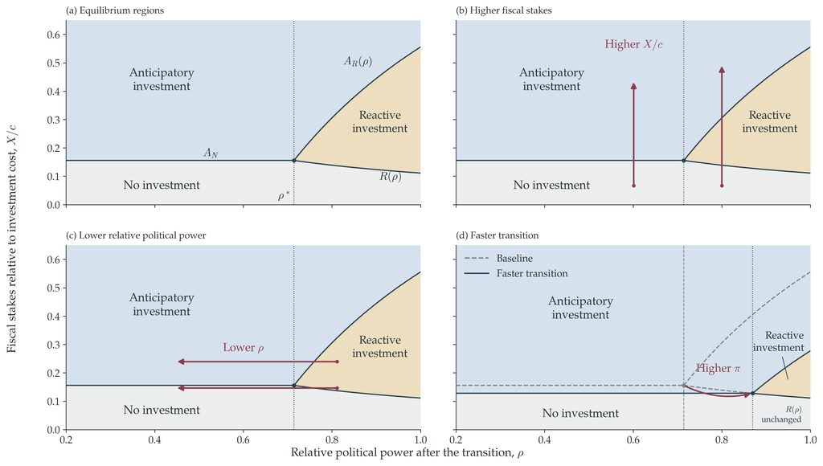

An increase in $X/c$ moves the case upwards. A decrease in $\rho$ moves it leftwards. An increase in $\pi$ shifts the anticipatory boundaries downwards and moves $\rho^*$ rightwards.

The figure uses $\beta=0.90$ and a baseline value $\pi=0.20$. The illustration of a faster transition uses $\pi'=0.40$. These parameter values are illustrative.

← Comparative statics